# COMPSCIX 415.2 Homework 2

### 5. What happens if you make a scatterplot of `class` vs `drv`? Why is the plot not useful?

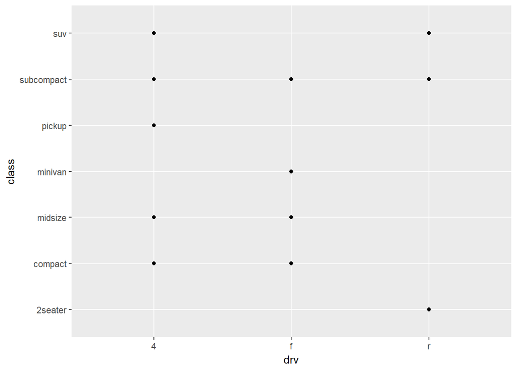

```r
ggplot(data=mpg) +
  geom_point(mapping=aes(x=drv, y=class))
```

Above is the scatterplot of `class` vs. `drv`. It’s not very useful because while there are probably multiple observations in the intersections of the categories of the two variables (e.g. midsize cars with four-wheel drive), from the plot you can’t tell how many observations there are in each intersection–only that there are observations.

## Section 3.3.1

### 1. What’s gone wrong with this code? Why are the points not blue?

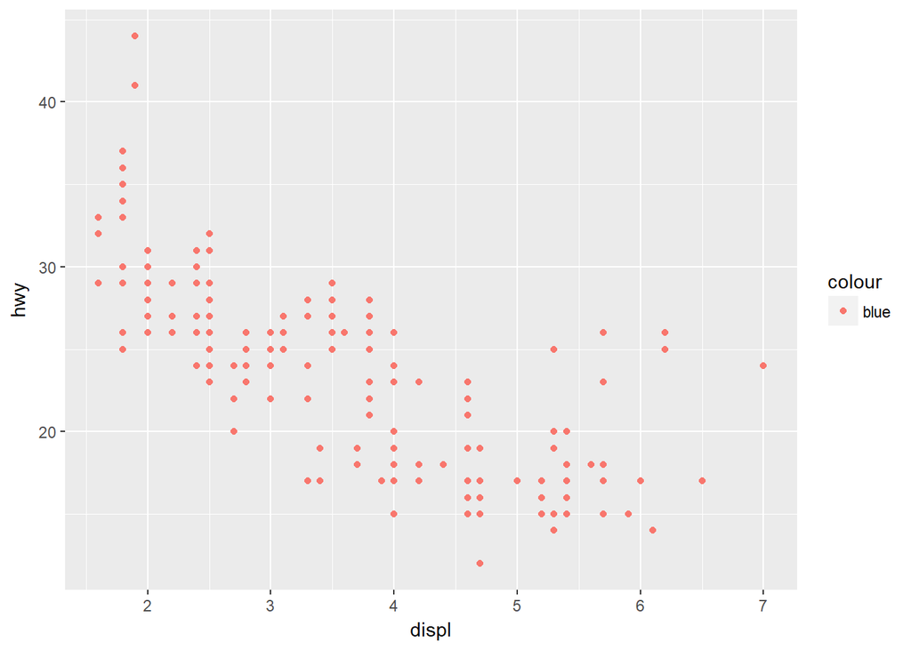

```r
ggplot(data = mpg) +
  geom_point(mapping = aes(x = displ, y = hwy, color = "blue"))
```

The issue with this code is that `color="blue"` is specified within `aes()` rather than outside of it. Since it’s specified within `aes()`, it looks like what `color="blue"` is doing is specifying the label for the color used in the scatterplot (and I guess orange is a default color).

### 2. Which variables in `mpg` are categorical? Which variables are continuous? (Hint: type `?mpg` to read the documentation for the dataset). How can you see this information when you run `mpg`?

The categorical variables in `mpg` are `manufacturer`, `model`, `year`, `cyl`, `trans`, `drv`, `fl`, `class`. The continuous variables are `displ`, `cty`, and `hwy`. You can also see this information by displaying the unique values of each variable.

```r
unique(mpg$cyl)
```

```
## [1] 4 6 8 5
```

```r
unique(mpg$displ)
```

```
##  [1] 1.8 2.0 2.8 3.1 4.2 5.3 5.7 6.0 6.2 7.0 6.5 2.4 3.5 3.6 3.0 3.3 3.8
## [18] 4.0 3.7 3.9 4.7 5.2 5.9 4.6 5.4 5.0 1.6 2.5 2.7 6.1 4.4 5.6 2.2 3.4
## [35] 1.9
```

### 3. Map a continuous variable to `color`, `size`, and `shape`. How do these aesthetics behave differently for categorical vs. continuous variables?

#### Mapping continuous and categorical variables to `color`:

##### Continuous:

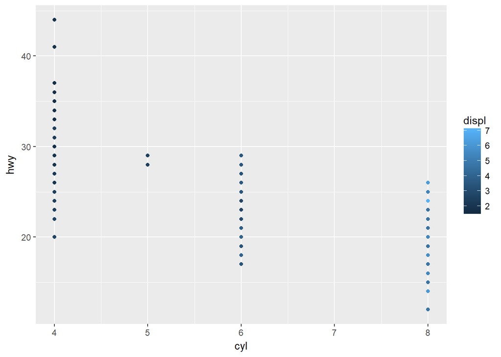

```r
ggplot(data=mpg) +
  geom_point(mapping=aes(x=cyl, y=hwy, color=displ))
```

##### Categorical:

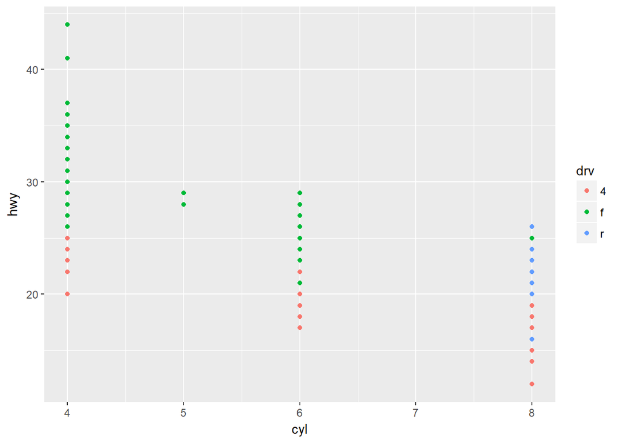

```r
ggplot(data=mpg) +
  geom_point(mapping=aes(x=cyl, y=hwy, color=drv))
```

The `color` aesthetic behaves differently when mapped to continuous versus categorical variables in that there is a different relationship between the colors it selects to represent each type of variable. For continuous variables, it provides a color gradient to illustrate where values are extreme. For categorical variables, it chooses colors with maximum contrast so that categories can be differentiated.

#### Mapping continuous and categorical variables to `size`:

##### Continuous:

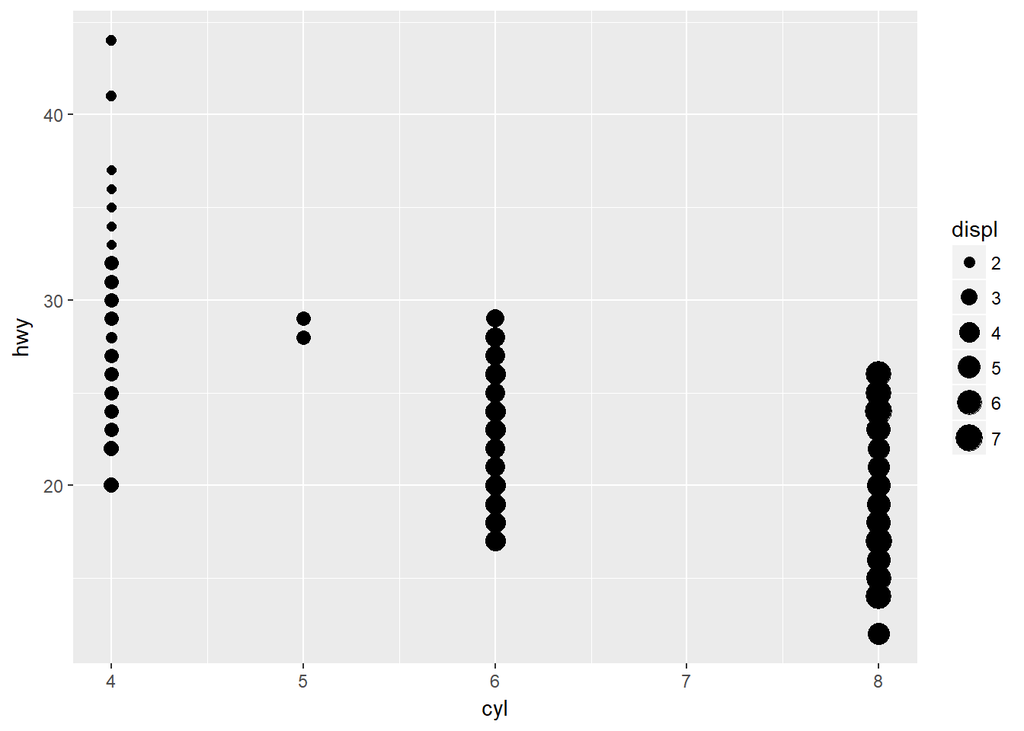

```r
ggplot(data=mpg) +
  geom_point(mapping=aes(x=cyl, y=hwy, size=displ))
```

##### Categorical:

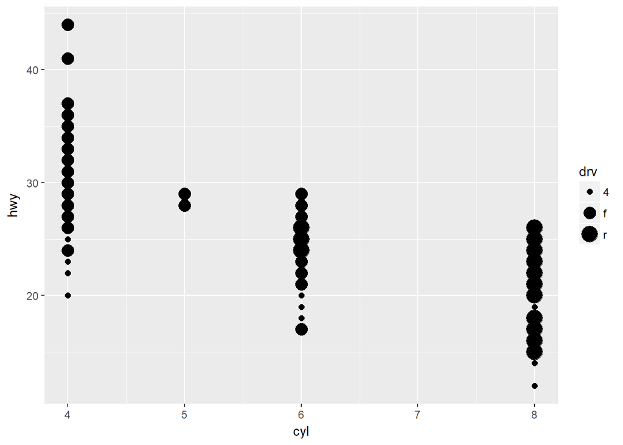

```r
ggplot(data=mpg) +
  geom_point(mapping=aes(x=cyl, y=hwy, size=drv))
```

The `size` aesthetic behaves differently when mapped to continuous versus categorical variables in that for continuous variables, there is a relationship between the size of the point and the value of the variable: the size of the point increases as the value of the variable increases. For categorical variables, the size of the point has no relationship to the variable’s categories, since the categories have no order to them.

#### Mapping continuous and categorical variables to `shape`:

##### Continuous:

```r
#ggplot(data=mpg) +
#  geom_point(mapping=aes(x=cyl, y=hwy, shape=displ))
```

Running this code produces the following error message: “Error: A continuous variable can not be mapped to shape”

##### Categorical:

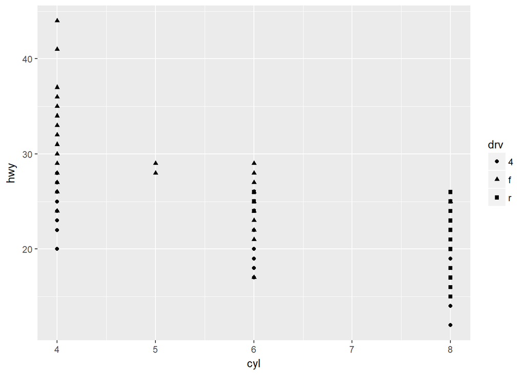

```r
ggplot(data=mpg) +
  geom_point(mapping=aes(x=cyl, y=hwy, shape=drv))
```

The `shape` aesthetic behaves differently when mapped to continuous versus categorical variables in that it doesn’t work for continuous variables (presumably because it doesn’t make sense to represent each value of the variable with a different shape). For categorical variables, `shape` represents each category with a different shape.

### 4. What happens if you map the same variable to multiple aesthetics?

If you map the same variable to multiple aesthetics, the graph combines the aesthetics. In the below scatterplot, `drv` is mapped to both `color` and `shape`, and so each category of `drv` is represented by a unique shape-color combination.

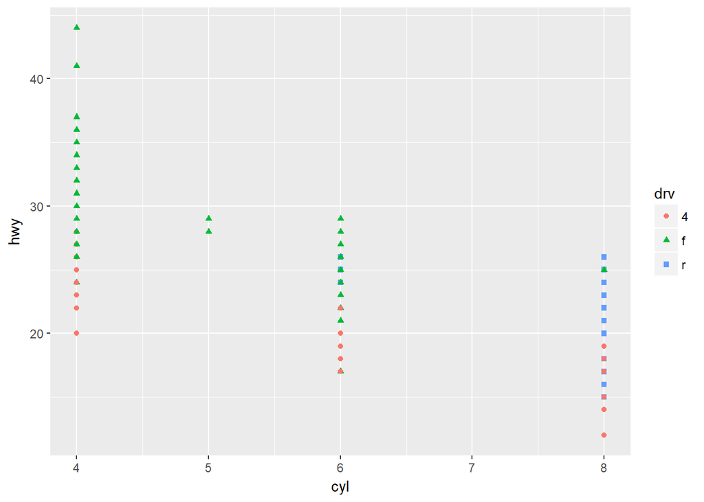

```r
ggplot(data=mpg) +
  geom_point(mapping=aes(x=cyl, y=hwy, color=drv, shape=drv))
```

### 5. What does the `stroke` aesthetic do? What shapes does it work with? (Hint: use `?geom_point`)

```r
?geom_point
```

The `stroke` aesthetic works with the filled shapes, 21 through 24, for which you can control the appearance of both the fill color and the outline. For those shapes, `stroke` changes the width of the outline.

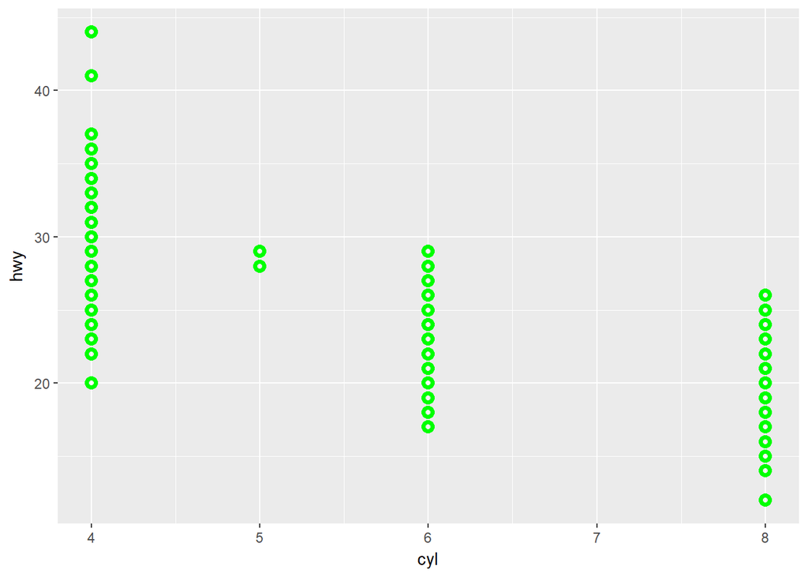

```r
ggplot(data=mpg) +
  geom_point(mapping=aes(x=cyl, y=hwy), shape=21, color="green", stroke=2)
```

### 6. What happens if you map an aesthetic to something other than a variable name, like `aes(colour = displ < 5)`?

If you map an aesthetic to a statement, rather than to a variable name, it applies a different visual effect to each observation according to whether the statement is true for the observation or not. In the below graph, observations for which `displ<5` is true are colored blue, whereas observations for which `displ<5` is false are colored orange.

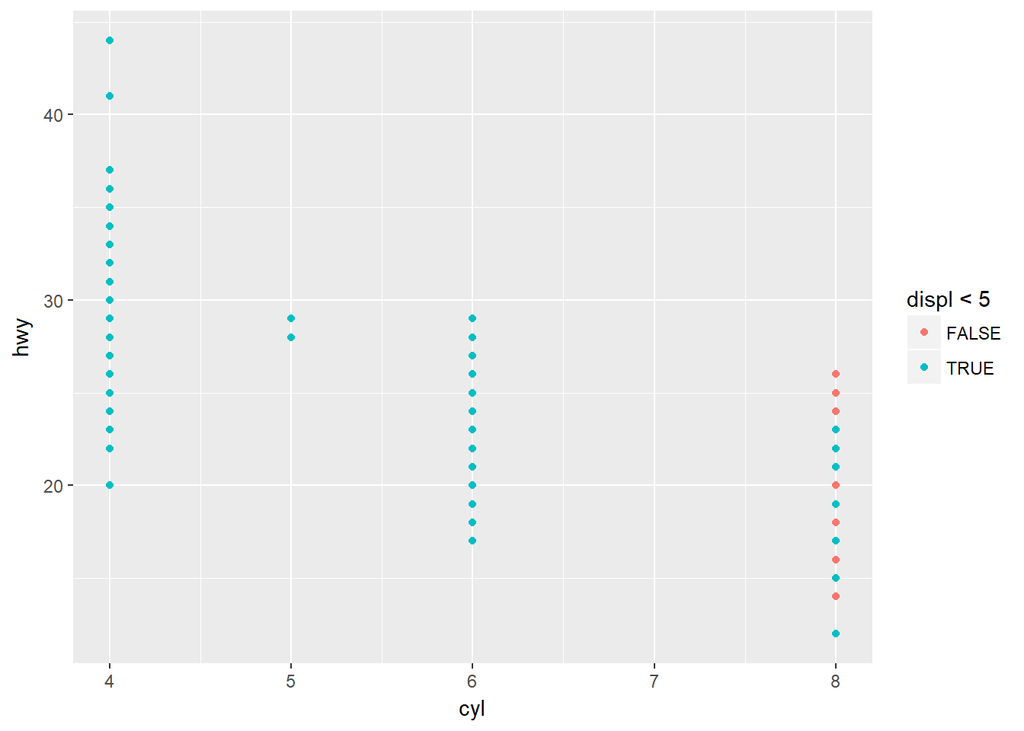

```r
ggplot(data=mpg) +
  geom_point(mapping=aes(x=cyl, y=hwy, color = displ<5))
```